# Nigeria Food Consumption

# Load the geopolitical zones

The geopolitical zones are a combination of states with similar ethnic groups, and/or common political history.

There are six zones:

| Zone name | States |
| --- | --- |
| North Central | Benue, Kogi, Kwara, Nasarawa, Niger, and Plateau States, and Federal Capital Territory |
| North East | Adamawa, Bauchi, Borno, Gombe, Taraba, and Yobe |
| North West | Jigawa, Kaduna, Kano, Katsina, Kebbi, Sokoto, and Zamfara |
| South East | Abia, Anambra, Ebonyi, Enugu, and Imo |
| South South | Akwa Ibom, Bayelsa, Cross River, Delta, Edo, and Rivers |
| South West | Ekiti, Lagos, Ogun, Ondo, Osun, and Oyo |

The zones are created by joining the states.

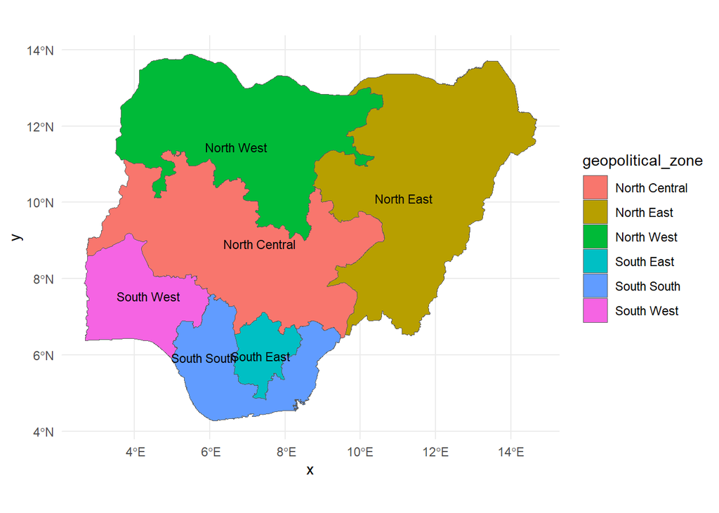

```r
adm1_pcode <- c("NG001", "NG002", "NG003", "NG004", "NG005", "NG006", "NG007", "NG008", "NG009", "NG010", "NG011", "NG012", "NG013", "NG014", "NG015", "NG016", "NG017", "NG018", "NG019", "NG020", "NG021", "NG022", "NG023", "NG024", "NG025", "NG026", "NG027", "NG028", "NG029", "NG030", "NG031", "NG032", "NG033", "NG034", "NG035", "NG036", "NG037")

geopolitical_zone<- c("South East", "North East", "South South", "South East", "North East", "South South", "North Central", "North East", "South South", "South South", "South East", "South South", "South West", "South East", "North Central", "North East", "South East", "North West", "North West", "North West", "North West", "North West", "North Central", "North Central", "South West", "North Central", "North Central", "South West", "South West", "South West", "South West", "North Central", "South South", "North West", "North East", "North East", "North West")

df_gpz <- tibble(adm1_pcode, geopolitical_zone)

vect_gpz_geo <- dplyr::left_join(vect_state_geo, df_gpz, by = c("adm1_pcode")) |> aggregate(by = "geopolitical_zone")

ggplot(vect_gpz_geo)+
  geom_spatvector(aes(fill = geopolitical_zone)) +
  geom_spatvector_text(aes(label = geopolitical_zone), size = 3) +
  theme_minimal()
```

# NFCMS 2021

## Load the NFCMS database

The NFCMS data are loaded and there are data available for the following zones:

```r
df_NFCMS <- read.csv("E:/repos/Biofort_Atlas_Nigeria/tab_data/NFCMS_consumption.csv")

df_NFCMS$geopolitical_zone <- as.factor(df_NFCMS$geopolitical_zone)

cat(paste(levels(df_NFCMS$geopolitical_zone), "; ")) # Check levels
```

North Central ; North East ; North West ; South East ; South South ; South West ;

```r
df_NFCMS_A10 <- read.csv("E:/repos/Biofort_Atlas_Nigeria/tab_data/NFCMS_A10_energy_top10.csv")

df_NFCMS_A10$geopolitical_zone <- as.factor(df_NFCMS_A10$geopolitical_zone)

cat(paste(levels(df_NFCMS_A10$geopolitical_zone), "; ")) # Check levels
```

North Central ; North East ; North West ; South East ; South South ; South West ;

```r
df_NFCMS_A12 <- read.csv("E:/repos/Biofort_Atlas_Nigeria/tab_data/NFCMS_A12_protein_top10.csv")

df_NFCMS_A12$geopolitical_zone <- as.factor(df_NFCMS_A12$geopolitical_zone)

cat(paste(levels(df_NFCMS_A12$geopolitical_zone), "; ")) # Check levels
```

North Central ; North East ; North West ; South East ; South South ; South West ;

```r
df_NFCMS_A17 <- read.csv("E:/repos/Biofort_Atlas_Nigeria/tab_data/NFCMS_A17_carb_top10.csv")

df_NFCMS_A17$geopolitical_zone <- as.factor(df_NFCMS_A17$geopolitical_zone)

cat(paste(levels(df_NFCMS_A17$geopolitical_zone), "; ")) # Check levels
```

North Central ; North East ; North West ; South East ; South South ; South West ;

```r
df_NFCMS_A19 <- read.csv("E:/repos/Biofort_Atlas_Nigeria/tab_data/NFCMS_A19_calc_top10.csv")

df_NFCMS_A19$geopolitical_zone <- as.factor(df_NFCMS_A19$geopolitical_zone)

cat(paste(levels(df_NFCMS_A19$geopolitical_zone), "; ")) # Check levels
```

North Central ; North East ; North West ; South East ; South South ; South West ;

```r
df_NFCMS_A21 <- read.csv("E:/repos/Biofort_Atlas_Nigeria/tab_data/NFCMS_A21_iron_top10.csv")

df_NFCMS_A21$geopolitical_zone <- as.factor(df_NFCMS_A21$geopolitical_zone)

cat(paste(levels(df_NFCMS_A21$geopolitical_zone), "; ")) # Check levels
```

North Central ; North East ; North West ; South East ; South South ; South West ;

```r
df_NFCMS_A23 <- read.csv("E:/repos/Biofort_Atlas_Nigeria/tab_data/NFCMS_A23_zinc_top10.csv")

df_NFCMS_A23$geopolitical_zone <- as.factor(df_NFCMS_A23$geopolitical_zone)

cat(paste(levels(df_NFCMS_A23$geopolitical_zone), "; ")) # Check levels
```

North Central ; North East ; North West ; South East ; South South ; South West ;

```r
df_NFCMS_A25 <- read.csv("E:/repos/Biofort_Atlas_Nigeria/tab_data/NFCMS_A25_vitA_top10.csv")

df_NFCMS_A25$geopolitical_zone <- as.factor(df_NFCMS_A25$geopolitical_zone)

cat(paste(levels(df_NFCMS_A25$geopolitical_zone), "; ")) # Check levels
```

North Central ; North East ; North West ; South East ; South South ; South West ;

## Join the NFCMS database to the zone dataset

The NFCMS dataset does not contain codes for the zones - only names. Therefore we need to join the two data frames using the name of the zone - and checking that all zones have data.

```r
vect_gpz_geo_NFCMS <- dplyr::left_join(vect_gpz_geo, df_NFCMS, by = c("geopolitical_zone"))
vect_gpz_geo_NFCMS |> as.data.frame() |>
  DT::datatable(
    rownames = F,
    caption = "NFCMS Consumption summary",
    filter = "bottom",
    selection = list(mode = "none"),
    editable = FALSE,
    options = list(
      digits = 0,
      scrollX = TRUE,
      scrollCollapse = TRUE,
      autoWidth = TRUE,
      fixedColumns = list(leftColumns = 2),
      lengthMenu = c(15, 40),
      pageLength = 15
    ))
```

| geopolitical_zone | mean_area_sqkm | mean_center_lat | mean_center_lon | id | valid_on | valid_to | adm0_pcode | adm0_name3 | adm1_ref_name | adm0_name2 | adm0_name | adm1_pcode | adm0_name1 | lang1 | lang3 | adm1_name3 | adm1_name2 | version | lang | adm1_name1 | adm1_name | lang2 | agg_n | WRA_cass_vit_A_pc_cons_fig10 | WRA_cass_vit_A_daily_122 | WRA_cass_vit_A_pc_energy_124 | WRA_cass_vit_A_pc_vit_A_126 | WRA_ofsp_pc_cons_fig12 | WRA_ofsp_daily_128 | … |
| --- | --- | --- | --- | --- | --- | --- | --- | --- | --- | --- | --- | --- | --- | --- | --- | --- | --- | --- | --- | --- | --- | --- | --- | --- | --- | --- | --- | --- | --- | --- |
| North Central | 32374.02856471428 | 8.683830957142858 | 7.281445614285714 |  | 2019-04-17T05:00:00Z |  | NG |  |  |  | Nigeria |  |  |  |  |  |  | v01 | en |  |  |  | 7 | 2.7 | 0.4 | 1.24 | 0.2 | 2.2 | 0.14 | … |
| North East | 46551.80045726667 | 10.41556971666667 | 11.36336905 |  | 2019-04-17T05:00:00Z |  | NG |  |  |  | Nigeria |  |  |  |  |  |  | v01 | en |  |  |  | 6 | 8.3 | 0.23 | 0.25 | 0.04 | 16.8 | 0.46 | … |
| North West | 30559.98868224286 | 11.78441014285714 | 6.968847014285714 |  | 2019-04-17T05:00:00Z |  | NG |  |  |  | Nigeria |  |  |  |  |  |  | v01 | en |  |  |  | 7 | 1 | 0.62 | 0.17 | 0.05 | 2.1 | 0.33 | … |
| South East | 5742.88735864 | 6.00114194 | 7.38378392 |  | 2019-04-17T05:00:00Z |  | NG |  |  |  | Nigeria |  |  |  |  |  |  | v01 | en |  |  |  | 5 | 4.1 | 1.36 | 1.82 | 0.13 | 2.1 | 0.22 | … |
| South South | 13999.63981785 | 5.508994833333333 | 6.726541516666667 |  | 2019-04-17T05:00:00Z |  | NG |  |  |  | Nigeria |  |  |  |  |  |  | v01 | en |  |  |  | 6 | 3.5 | 6.33 | 0.56 | 0.05 | 2.5 | 0.37 | … |
| South West | 12895.26095053333 | 7.309125083333333 | 4.21263045 |  | 2019-04-17T05:00:00Z |  | NG |  |  |  | Nigeria |  |  |  |  |  |  | v01 | en |  |  |  | 6 | 1.7 | 0.46 | 1.6 | 0.21 | 2.3 | 0.04 | … |

```r
vect_gpz_geo_NFCMS_A10 <- dplyr::left_join(vect_gpz_geo, df_NFCMS_A10, by = c("geopolitical_zone"))
vect_gpz_geo_NFCMS_A10 |> as.data.frame() |>
  DT::datatable(
    rownames = F,
    caption = "NFCMS Energy top 10",
    filter = "bottom",
    selection = list(mode = "none"),
    editable = FALSE,
    options = list(
      digits = 0,
      scrollX = TRUE,
      scrollCollapse = TRUE,
      autoWidth = TRUE,
      fixedColumns = list(leftColumns = 2),
      lengthMenu = c(15, 40),
      pageLength = 15
    ))
```

| geopolitical_zone | mean_area_sqkm | mean_center_lat | mean_center_lon | id | valid_on | valid_to | adm0_pcode | adm0_name3 | adm1_ref_name | adm0_name2 | adm0_name | adm1_pcode | adm0_name1 | lang1 | lang3 | adm1_name3 | adm1_name2 | version | lang | adm1_name1 | adm1_name | lang2 | agg_n | SN1_Name | SN1_kcal | SN1_pc | SN2_Name | SN2_kcal | SN2_pc | … |
| --- | --- | --- | --- | --- | --- | --- | --- | --- | --- | --- | --- | --- | --- | --- | --- | --- | --- | --- | --- | --- | --- | --- | --- | --- | --- | --- | --- | --- | --- | --- |
| North Central | 32374.02856471428 | 8.683830957142858 | 7.281445614285714 |  | 2019-04-17T05:00:00Z |  | NG |  |  |  | Nigeria |  |  |  |  |  |  | v01 | en |  |  |  | 7 | Rice | 206.6 | 12.5 | Palm olein | 194.4 | 11.7 | … |
| North East | 46551.80045726667 | 10.41556971666667 | 11.36336905 |  | 2019-04-17T05:00:00Z |  | NG |  |  |  | Nigeria |  |  |  |  |  |  | v01 | en |  |  |  | 6 | Palm olein | 266.8 | 15.1 | *Maize flour | 177.7 | 10.1 | … |
| North West | 30559.98868224286 | 11.78441014285714 | 6.968847014285714 |  | 2019-04-17T05:00:00Z |  | NG |  |  |  | Nigeria |  |  |  |  |  |  | v01 | en |  |  |  | 7 | Palm olein | 320.8 | 16.1 | Maize products | 201.1 | 10.1 | … |
| South East | 5742.88735864 | 6.00114194 | 7.38378392 |  | 2019-04-17T05:00:00Z |  | NG |  |  |  | Nigeria |  |  |  |  |  |  | v01 | en |  |  |  | 5 | Rice | 241.1 | 11.8 | Palm oil | 220.6 | 10.8 | … |
| South South | 13999.63981785 | 5.508994833333333 | 6.726541516666667 |  | 2019-04-17T05:00:00Z |  | NG |  |  |  | Nigeria |  |  |  |  |  |  | v01 | en |  |  |  | 6 | Garri | 305.6 | 15.4 | Palm oil | 240.8 | 12.2 | … |
| South West | 12895.26095053333 | 7.309125083333333 | 4.21263045 |  | 2019-04-17T05:00:00Z |  | NG |  |  |  | Nigeria |  |  |  |  |  |  | v01 | en |  |  |  | 6 | Rice | 247.1 | 13.4 | Palm oil | 212.8 | 11.5 | … |

```r
vect_gpz_geo_NFCMS_A12 <- dplyr::left_join(vect_gpz_geo, df_NFCMS_A12, by = c("geopolitical_zone"))
vect_gpz_geo_NFCMS_A12 |> as.data.frame() |>
  DT::datatable(
    rownames = F,
    caption = "NFCMS Protein top 10",
    filter = "bottom",
    selection = list(mode = "none"),
    editable = FALSE,
    options = list(
      digits = 0,
      scrollX = TRUE,
      scrollCollapse = TRUE,
      autoWidth = TRUE,
      fixedColumns = list(leftColumns = 2),
      lengthMenu = c(15, 40),
      pageLength = 15
    ))
```

| geopolitical_zone | mean_area_sqkm | mean_center_lat | mean_center_lon | id | valid_on | valid_to | adm0_pcode | adm0_name3 | adm1_ref_name | adm0_name2 | adm0_name | adm1_pcode | adm0_name1 | lang1 | lang3 | adm1_name3 | adm1_name2 | version | lang | adm1_name1 | adm1_name | lang2 | agg_n | SN1_Name | SN1_g | SN1_pc | SN2_Name | SN2_g | SN2_pc | … |
| --- | --- | --- | --- | --- | --- | --- | --- | --- | --- | --- | --- | --- | --- | --- | --- | --- | --- | --- | --- | --- | --- | --- | --- | --- | --- | --- | --- | --- | --- | --- |
| North Central | 32374.02856471428 | 8.683830957142858 | 7.281445614285714 |  | 2019-04-17T05:00:00Z |  | NG |  |  |  | Nigeria |  |  |  |  |  |  | v01 | en |  |  |  | 7 | Rice | 4.6 | 11 | Maize products | 4.1 | 9.8 | … |
| North East | 46551.80045726667 | 10.41556971666667 | 11.36336905 |  | 2019-04-17T05:00:00Z |  | NG |  |  |  | Nigeria |  |  |  |  |  |  | v01 | en |  |  |  | 6 | *Maize flour | 5 | 11.7 | Rice | 3.6 | 8.4 | … |
| North West | 30559.98868224286 | 11.78441014285714 | 6.968847014285714 |  | 2019-04-17T05:00:00Z |  | NG |  |  |  | Nigeria |  |  |  |  |  |  | v01 | en |  |  |  | 7 | Maize products | 5 | 10.2 | Rice | 3.8 | 7.9 | … |
| South East | 5742.88735864 | 6.00114194 | 7.38378392 |  | 2019-04-17T05:00:00Z |  | NG |  |  |  | Nigeria |  |  |  |  |  |  | v01 | en |  |  |  | 5 | Rice | 5.4 | 10.6 | Beef | 3.6 | 7.1 | … |
| South South | 13999.63981785 | 5.508994833333333 | 6.726541516666667 |  | 2019-04-17T05:00:00Z |  | NG |  |  |  | Nigeria |  |  |  |  |  |  | v01 | en |  |  |  | 6 | Rice | 4.9 | 9.8 | Beef | 4.5 | 9 | … |
| South West | 12895.26095053333 | 7.309125083333333 | 4.21263045 |  | 2019-04-17T05:00:00Z |  | NG |  |  |  | Nigeria |  |  |  |  |  |  | v01 | en |  |  |  | 6 | Rice | 5.4 | 10 | Hake fish | 4.5 | 8.3 | … |

```r
vect_gpz_geo_NFCMS_A17 <- dplyr::left_join(vect_gpz_geo, df_NFCMS_A17, by = c("geopolitical_zone"))
vect_gpz_geo_NFCMS_A17 |> as.data.frame() |>
  DT::datatable(
    rownames = F,
    caption = "NFCMS Carbohydrate top 10",
    filter = "bottom",
    selection = list(mode = "none"),
    editable = FALSE,
    options = list(
      digits = 0,
      scrollX = TRUE,
      scrollCollapse = TRUE,
      autoWidth = TRUE,
      fixedColumns = list(leftColumns = 2),
      lengthMenu = c(15, 40),
      pageLength = 15
    ))
```

| geopolitical_zone | mean_area_sqkm | mean_center_lat | mean_center_lon | id | valid_on | valid_to | adm0_pcode | adm0_name3 | adm1_ref_name | adm0_name2 | adm0_name | adm1_pcode | adm0_name1 | lang1 | lang3 | adm1_name3 | adm1_name2 | version | lang | adm1_name1 | adm1_name | lang2 | agg_n | SN1_Name | SN1_g | SN1_pc | SN2_Name | SN2_g | SN2_pc | … |
| --- | --- | --- | --- | --- | --- | --- | --- | --- | --- | --- | --- | --- | --- | --- | --- | --- | --- | --- | --- | --- | --- | --- | --- | --- | --- | --- | --- | --- | --- | --- |
| North Central | 32374.02856471428 | 8.683830957142858 | 7.281445614285714 |  | 2019-04-17T05:00:00Z |  | NG |  |  |  | Nigeria |  |  |  |  |  |  | v01 | en |  |  |  | 7 | Rice | 44.2 | 19.2 | Maize products | 33.3 | 14.5 | … |
| North East | 46551.80045726667 | 10.41556971666667 | 11.36336905 |  | 2019-04-17T05:00:00Z |  | NG |  |  |  | Nigeria |  |  |  |  |  |  | v01 | en |  |  |  | 6 | Rice | 35.3 | 14.7 | *Maize flour | 32.6 | 13.6 | … |
| North West | 30559.98868224286 | 11.78441014285714 | 6.968847014285714 |  | 2019-04-17T05:00:00Z |  | NG |  |  |  | Nigeria |  |  |  |  |  |  | v01 | en |  |  |  | 7 | Maize products | 39.3 | 14.4 | Rice | 36.5 | 13.4 | … |
| South East | 5742.88735864 | 6.00114194 | 7.38378392 |  | 2019-04-17T05:00:00Z |  | NG |  |  |  | Nigeria |  |  |  |  |  |  | v01 | en |  |  |  | 5 | Rice | 51.8 | 19.4 | Garri | 49.1 | 18.3 | … |
| South South | 13999.63981785 | 5.508994833333333 | 6.726541516666667 |  | 2019-04-17T05:00:00Z |  | NG |  |  |  | Nigeria |  |  |  |  |  |  | v01 | en |  |  |  | 6 | Garri | 71.3 | 27.3 | Rice | 46.8 | 17.9 | … |
| South West | 12895.26095053333 | 7.309125083333333 | 4.21263045 |  | 2019-04-17T05:00:00Z |  | NG |  |  |  | Nigeria |  |  |  |  |  |  | v01 | en |  |  |  | 6 | Rice | 53.8 | 21.3 | Garri | 30.5 | 12.1 | … |

```r
vect_gpz_geo_NFCMS_A19 <- dplyr::left_join(vect_gpz_geo, df_NFCMS_A19, by = c("geopolitical_zone"))
vect_gpz_geo_NFCMS_A19 |> as.data.frame() |>
  DT::datatable(
    rownames = F,
    caption = "NFCMS Calcium top 10",
    filter = "bottom",
    selection = list(mode = "none"),
    editable = FALSE,
    options = list(
      digits = 0,
      scrollX = TRUE,
      scrollCollapse = TRUE,
      autoWidth = TRUE,
      fixedColumns = list(leftColumns = 2),
      lengthMenu = c(15, 40),
      pageLength = 15
    ))
```

| geopolitical_zone | mean_area_sqkm | mean_center_lat | mean_center_lon | id | valid_on | valid_to | adm0_pcode | adm0_name3 | adm1_ref_name | adm0_name2 | adm0_name | adm1_pcode | adm0_name1 | lang1 | lang3 | adm1_name3 | adm1_name2 | version | lang | adm1_name1 | adm1_name | lang2 | agg_n | SN1_Name | SN1_g | SN1_pc | SN2_Name | SN2_g | SN2_pc | … |
| --- | --- | --- | --- | --- | --- | --- | --- | --- | --- | --- | --- | --- | --- | --- | --- | --- | --- | --- | --- | --- | --- | --- | --- | --- | --- | --- | --- | --- | --- | --- |
| North Central | 32374.02856471428 | 8.683830957142858 | 7.281445614285714 |  | 2019-04-17T05:00:00Z |  | NG |  |  |  | Nigeria |  |  |  |  |  |  | v01 | en |  |  |  | 7 | Bread | 33.6 | 8.8 | *Condiments | 28.9 | 7.6 | … |
| North East | 46551.80045726667 | 10.41556971666667 | 11.36336905 |  | 2019-04-17T05:00:00Z |  | NG |  |  |  | Nigeria |  |  |  |  |  |  | v01 | en |  |  |  | 6 | *Condiments | 47.3 | 13 | Dried baobab powder | 46.5 | 12.8 | … |
| North West | 30559.98868224286 | 11.78441014285714 | 6.968847014285714 |  | 2019-04-17T05:00:00Z |  | NG |  |  |  | Nigeria |  |  |  |  |  |  | v01 | en |  |  |  | 7 | Fura da nono | 81.8 | 18.1 | Condiment | 52.1 | 11.5 | … |
| South East | 5742.88735864 | 6.00114194 | 7.38378392 |  | 2019-04-17T05:00:00Z |  | NG |  |  |  | Nigeria |  |  |  |  |  |  | v01 | en |  |  |  | 5 | Shellfish | 116.6 | 19.4 | Bread | 68.5 | 11.4 | … |
| South South | 13999.63981785 | 5.508994833333333 | 6.726541516666667 |  | 2019-04-17T05:00:00Z |  | NG |  |  |  | Nigeria |  |  |  |  |  |  | v01 | en |  |  |  | 6 | Shellfish | 112 | 18.8 | Bread | 73.2 | 12.3 | … |
| South West | 12895.26095053333 | 7.309125083333333 | 4.21263045 |  | 2019-04-17T05:00:00Z |  | NG |  |  |  | Nigeria |  |  |  |  |  |  | v01 | en |  |  |  | 6 | Bread | 91.1 | 16.4 | Hake fish | 58 | 10.5 | … |

```r
vect_gpz_geo_NFCMS_A21 <- dplyr::left_join(vect_gpz_geo, df_NFCMS_A21, by = c("geopolitical_zone"))
vect_gpz_geo_NFCMS_A21 |> as.data.frame() |>
  DT::datatable(
    rownames = F,
    caption = "NFCMS Iron top 10",
    filter = "bottom",
    selection = list(mode = "none"),
    editable = FALSE,
    options = list(
      digits = 0,
      scrollX = TRUE,
      scrollCollapse = TRUE,
      autoWidth = TRUE,
      fixedColumns = list(leftColumns = 2),
      lengthMenu = c(15, 40),
      pageLength = 15
    ))
```

| geopolitical_zone | mean_area_sqkm | mean_center_lat | mean_center_lon | id | valid_on | valid_to | adm0_pcode | adm0_name3 | adm1_ref_name | adm0_name2 | adm0_name | adm1_pcode | adm0_name1 | lang1 | lang3 | adm1_name3 | adm1_name2 | version | lang | adm1_name1 | adm1_name | lang2 | agg_n | SN1_Name | SN1_g | SN1_pc | SN2_Name | SN2_g | SN2_pc | … |
| --- | --- | --- | --- | --- | --- | --- | --- | --- | --- | --- | --- | --- | --- | --- | --- | --- | --- | --- | --- | --- | --- | --- | --- | --- | --- | --- | --- | --- | --- | --- |
| North Central | 32374.02856471428 | 8.683830957142858 | 7.281445614285714 |  | 2019-04-17T05:00:00Z |  | NG |  |  |  | Nigeria |  |  |  |  |  |  | v01 | en |  |  |  | 7 | *Condiments | 1.9 | 13.5 | Maize products | 1.4 | 10 | … |
| North East | 46551.80045726667 | 10.41556971666667 | 11.36336905 |  | 2019-04-17T05:00:00Z |  | NG |  |  |  | Nigeria |  |  |  |  |  |  | v01 | en |  |  |  | 6 | *Condiments | 4.1 | 24.2 | *Maize flour | 1.4 | 8.2 | … |
| North West | 30559.98868224286 | 11.78441014285714 | 6.968847014285714 |  | 2019-04-17T05:00:00Z |  | NG |  |  |  | Nigeria |  |  |  |  |  |  | v01 | en |  |  |  | 7 | *Condiments | 4.3 | 21.7 | Millet products | 3.2 | 16.2 | … |
| South East | 5742.88735864 | 6.00114194 | 7.38378392 |  | 2019-04-17T05:00:00Z |  | NG |  |  |  | Nigeria |  |  |  |  |  |  | v01 | en |  |  |  | 5 | Garri | 1.8 | 11.7 | *Condiments | 1.3 | 8.1 | … |
| South South | 13999.63981785 | 5.508994833333333 | 6.726541516666667 |  | 2019-04-17T05:00:00Z |  | NG |  |  |  | Nigeria |  |  |  |  |  |  | v01 | en |  |  |  | 6 | Garri | 2.5 | 17.1 | Shellfish | 1.1 | 7.5 | … |
| South West | 12895.26095053333 | 7.309125083333333 | 4.21263045 |  | 2019-04-17T05:00:00Z |  | NG |  |  |  | Nigeria |  |  |  |  |  |  | v01 | en |  |  |  | 6 | Rice | 1.4 | 9.7 | Bread | 1.3 | 8.7 | … |

```r
vect_gpz_geo_NFCMS_A23 <- dplyr::left_join(vect_gpz_geo, df_NFCMS_A23, by = c("geopolitical_zone"))
vect_gpz_geo_NFCMS_A23 |> as.data.frame() |>
  DT::datatable(
    rownames = F,
    caption = "NFCMS Zinc top 10",
    filter = "bottom",
    selection = list(mode = "none"),
    editable = FALSE,
    options = list(
      digits = 0,
      scrollX = TRUE,
      scrollCollapse = TRUE,
      autoWidth = TRUE,
      fixedColumns = list(leftColumns = 2),
      lengthMenu = c(15, 40),
      pageLength = 15
    ))
```

| geopolitical_zone | mean_area_sqkm | mean_center_lat | mean_center_lon | id | valid_on | valid_to | adm0_pcode | adm0_name3 | adm1_ref_name | adm0_name2 | adm0_name | adm1_pcode | adm0_name1 | lang1 | lang3 | adm1_name3 | adm1_name2 | version | lang | adm1_name1 | adm1_name | lang2 | agg_n | SN1_Name | SN1_g | SN1_pc | SN2_Name | SN2_g | SN2_pc | … |
| --- | --- | --- | --- | --- | --- | --- | --- | --- | --- | --- | --- | --- | --- | --- | --- | --- | --- | --- | --- | --- | --- | --- | --- | --- | --- | --- | --- | --- | --- | --- |
| North Central | 32374.02856471428 | 8.683830957142858 | 7.281445614285714 |  | 2019-04-17T05:00:00Z |  | NG |  |  |  | Nigeria |  |  |  |  |  |  | v01 | en |  |  |  | 7 | Maize products | 1 | 13.4 | Rice | 0.9 | 12.6 | … |
| North East | 46551.80045726667 | 10.41556971666667 | 11.36336905 |  | 2019-04-17T05:00:00Z |  | NG |  |  |  | Nigeria |  |  |  |  |  |  | v01 | en |  |  |  | 6 | *Maize flour | 1 | 14.3 | Rice | 0.8 | 11 | … |
| North West | 30559.98868224286 | 11.78441014285714 | 6.968847014285714 |  | 2019-04-17T05:00:00Z |  | NG |  |  |  | Nigeria |  |  |  |  |  |  | v01 | en |  |  |  | 7 | Maize products | 1.2 | 15 | Millet products | 1 | 12.5 | … |
| South East | 5742.88735864 | 6.00114194 | 7.38378392 |  | 2019-04-17T05:00:00Z |  | NG |  |  |  | Nigeria |  |  |  |  |  |  | v01 | en |  |  |  | 5 | Garri | 2.7 | 26.6 | Rice | 1.1 | 10.7 | … |
| South South | 13999.63981785 | 5.508994833333333 | 6.726541516666667 |  | 2019-04-17T05:00:00Z |  | NG |  |  |  | Nigeria |  |  |  |  |  |  | v01 | en |  |  |  | 6 | Garri | 3.3 | 30.3 | Rice | 1 | 9.1 | … |
| South West | 12895.26095053333 | 7.309125083333333 | 4.21263045 |  | 2019-04-17T05:00:00Z |  | NG |  |  |  | Nigeria |  |  |  |  |  |  | v01 | en |  |  |  | 6 | Garri | 3.3 | 30.3 | Rice | 1 | 9.1 | … |

```r
vect_gpz_geo_NFCMS_A25 <- dplyr::left_join(vect_gpz_geo, df_NFCMS_A25, by = c("geopolitical_zone"))
vect_gpz_geo_NFCMS_A25 |> as.data.frame() |>
  DT::datatable(
    rownames = F,
    caption = "NFCMS Vitamin A top 10",
    filter = "bottom",
    selection = list(mode = "none"),
    editable = FALSE,
    options = list(
      digits = 0,
      scrollX = TRUE,
      scrollCollapse = TRUE,
      autoWidth = TRUE,
      fixedColumns = list(leftColumns = 2),
      lengthMenu = c(15, 40),
      pageLength = 15
    ))
```

| geopolitical_zone | mean_area_sqkm | mean_center_lat | mean_center_lon | id | valid_on | valid_to | adm0_pcode | adm0_name3 | adm1_ref_name | adm0_name2 | adm0_name | adm1_pcode | adm0_name1 | lang1 | lang3 | adm1_name3 | adm1_name2 | version | lang | adm1_name1 | adm1_name | lang2 | agg_n | SN1_Name | SN1_mcg | SN1_pc | SN2_Name | SN2_mcg | SN2_pc | … |
| --- | --- | --- | --- | --- | --- | --- | --- | --- | --- | --- | --- | --- | --- | --- | --- | --- | --- | --- | --- | --- | --- | --- | --- | --- | --- | --- | --- | --- | --- | --- |
| North Central | 32374.02856471428 | 8.683830957142858 | 7.281445614285714 |  | 2019-04-17T05:00:00Z |  | NG |  |  |  | Nigeria |  |  |  |  |  |  | v01 | en |  |  |  | 7 | Palm oil | 490.4 | 64.7 | Palm olein | 53.3 | 7 | … |
| North East | 46551.80045726667 | 10.41556971666667 | 11.36336905 |  | 2019-04-17T05:00:00Z |  | NG |  |  |  | Nigeria |  |  |  |  |  |  | v01 | en |  |  |  | 6 | Palm oil | 418.8 | 60.3 | Palm olein | 73.1 | 10.5 | … |
| North West | 30559.98868224286 | 11.78441014285714 | 6.968847014285714 |  | 2019-04-17T05:00:00Z |  | NG |  |  |  | Nigeria |  |  |  |  |  |  | v01 | en |  |  |  | 7 | Palm oil | 337.1 | 51.8 | Palm olein | 88.3 | 13.6 | … |
| South East | 5742.88735864 | 6.00114194 | 7.38378392 |  | 2019-04-17T05:00:00Z |  | NG |  |  |  | Nigeria |  |  |  |  |  |  | v01 | en |  |  |  | 5 | Palm oil | 817.4 | 51.8 | Banga | 431.4 | 27.3 | … |
| South South | 13999.63981785 | 5.508994833333333 | 6.726541516666667 |  | 2019-04-17T05:00:00Z |  | NG |  |  |  | Nigeria |  |  |  |  |  |  | v01 | en |  |  |  | 6 | Palm oil | 906.6 | 57.2 | Banga | 384.9 | 24.3 | … |
| South West | 12895.26095053333 | 7.309125083333333 | 4.21263045 |  | 2019-04-17T05:00:00Z |  | NG |  |  |  | Nigeria |  |  |  |  |  |  | v01 | en |  |  |  | 6 | Palm oil | 760.3 | 72.5 | Palm olein | 36.4 | 3.5 | … |

# GHS 2023-24

Many of the relevant indicators are already summarised by geopolitical zone and are displayed in the GHS report. These are pre-digitised and are loaded as a single csv file.

## Load the GHS database

```r
df_GHS <- read.csv("E:/repos/Biofort_Atlas_Nigeria/tab_data/GHS_consumption.csv")

df_GHS$geopolitical_zone <- as.factor(df_GHS$geopolitical_zone)

cat(paste(levels(df_GHS$geopolitical_zone), "; ")) # Check levels
```

North Central ; North East ; North West ; South East ; South South ; South West ;

## Join the GHS database to the zone dataset

The GHS dataset does not contain codes for the zones - only names. Therefore we need to join the two data frames using the name of the zone - and checking that all zones have data.

```r
vect_gpz_geo_GHS <- dplyr::left_join(vect_gpz_geo, df_GHS, by = c("geopolitical_zone"))
vect_gpz_geo_GHS |> as.data.frame() |>
  DT::datatable(
    rownames = F,
    filter = "bottom",
    selection = list(mode = "none"),
    editable = FALSE,
    options = list(
      digits = 0,
      scrollX = TRUE,
      scrollCollapse = TRUE,
      autoWidth = TRUE,
      fixedColumns = list(leftColumns = 2),
      lengthMenu = c(15, 40),
      pageLength = 15
    ))
```

| geopolitical_zone | mean_area_sqkm | mean_center_lat | mean_center_lon | id | valid_on | valid_to | adm0_pcode | adm0_name3 | adm1_ref_name | adm0_name2 | adm0_name | adm1_pcode | adm0_name1 | lang1 | lang3 | adm1_name3 | adm1_name2 | version | lang | adm1_name1 | adm1_name | lang2 | agg_n | gr_rtb | pulses | nut_seeds | dairy | meat_fish | eggs | … |
| --- | --- | --- | --- | --- | --- | --- | --- | --- | --- | --- | --- | --- | --- | --- | --- | --- | --- | --- | --- | --- | --- | --- | --- | --- | --- | --- | --- | --- | --- | --- |
| North Central | 32374.02856471428 | 8.683830957142858 | 7.281445614285714 |  | 2019-04-17T05:00:00Z |  | NG |  |  |  | Nigeria |  |  |  |  |  |  | v01 | en |  |  |  | 7 | 94.7 | 60.9 | 22.6 | 9.6 | 50 | 3.6 | … |
| North East | 46551.80045726667 | 10.41556971666667 | 11.36336905 |  | 2019-04-17T05:00:00Z |  | NG |  |  |  | Nigeria |  |  |  |  |  |  | v01 | en |  |  |  | 6 | 94.4 | 73.8 | 53 | 20.5 | 42.4 | 3.6 | … |
| North West | 30559.98868224286 | 11.78441014285714 | 6.968847014285714 |  | 2019-04-17T05:00:00Z |  | NG |  |  |  | Nigeria |  |  |  |  |  |  | v01 | en |  |  |  | 7 | 96.6 | 77.3 | 28.4 | 37.2 | 29.3 | 3.9 | … |
| South East | 5742.88735864 | 6.00114194 | 7.38378392 |  | 2019-04-17T05:00:00Z |  | NG |  |  |  | Nigeria |  |  |  |  |  |  | v01 | en |  |  |  | 5 | 92.7 | 52.6 | 53.6 | 21.2 | 68.1 | 8.4 | … |
| South South | 13999.63981785 | 5.508994833333333 | 6.726541516666667 |  | 2019-04-17T05:00:00Z |  | NG |  |  |  | Nigeria |  |  |  |  |  |  | v01 | en |  |  |  | 6 | 88.8 | 38 | 49.6 | 26.2 | 80.2 | 19.4 | … |
| South West | 12895.26095053333 | 7.309125083333333 | 4.21263045 |  | 2019-04-17T05:00:00Z |  | NG |  |  |  | Nigeria |  |  |  |  |  |  | v01 | en |  |  |  | 6 | 96.1 | 66.9 | 20.8 | 19.9 | 74.6 | 23 | … |

# Compare data sources

To help select the best data source it is necessary to compare the statistics for each indicator from the two sources. However, the indicators in the National Food Consumption and Micronutrient Survey are in many cases different to the GHS survey. The indicators that are most similar are the values for dietary diversity.

# Women’s Minimum Dietary Diversity (MDD-W)

MDD-W is an indicator that measures the proportion of women 15-49 years of age who consumed food items (at least 15g) from at least five out of the ten defined food groups the previous day or night. The higher the MDD-W, the higher the probability of nutrient adequacy for most key micro-nutrients needed for sustenance of health.

There are two indicators in the datasets for MDD-W: 1) the percentage of women achieving the MDD 2) the average MDD score

## MDD-W (NFCMS, 2021)

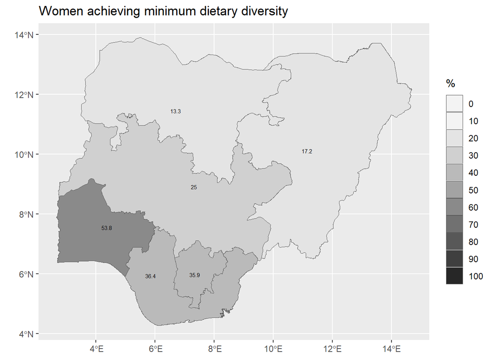

```r
ggplot(vect_gpz_geo_NFCMS) +
  geom_spatvector(aes(fill = MDD_PC_W_179)) +
  geom_spatvector_text(aes(label = MDD_PC_W_179), size = 2) +
  scale_fill_stepsn(
    n.breaks = 10,
    limits = c(0, 100),
    colours = hcl.colors(palette = "Grays", 10, rev = T),
    guide = "legend",
    na.value = "pink",
    labels = scales::comma
  ) +
  labs(title = "Women achieving minimum dietary diversity", fill = "%") +
  theme(
    plot.title = element_markdown(),
    legend.title = element_markdown(),
    axis.title = element_blank()
  )
```

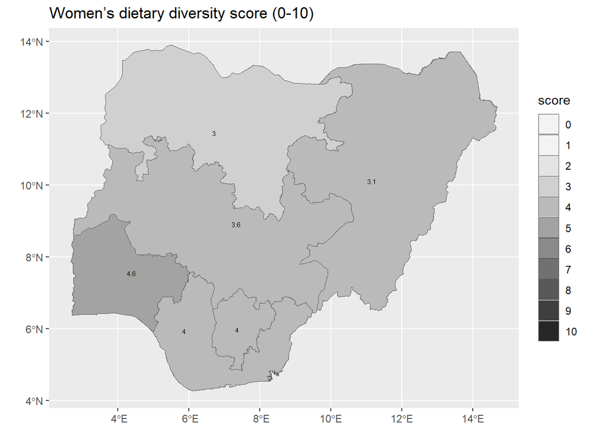

```r
ggplot(vect_gpz_geo_NFCMS) +
  geom_spatvector(aes(fill = MDD_W_180)) +
  geom_spatvector_text(aes(label = MDD_W_180), size = 2) +
  scale_fill_stepsn(
    n.breaks = 10,
    limits = c(0, 10),
    colours = hcl.colors(palette = "Grays", 10, rev = T),
    guide = "legend",
    na.value = "pink",
    labels = scales::comma
  ) +
  labs(title = "Women's dietary diversity score (0-10)", fill = "score") +
  theme(
    plot.title = element_markdown(),
    legend.title = element_markdown(),
    axis.title = element_blank()
  )
```

## MDD-W (GHS, 2024)

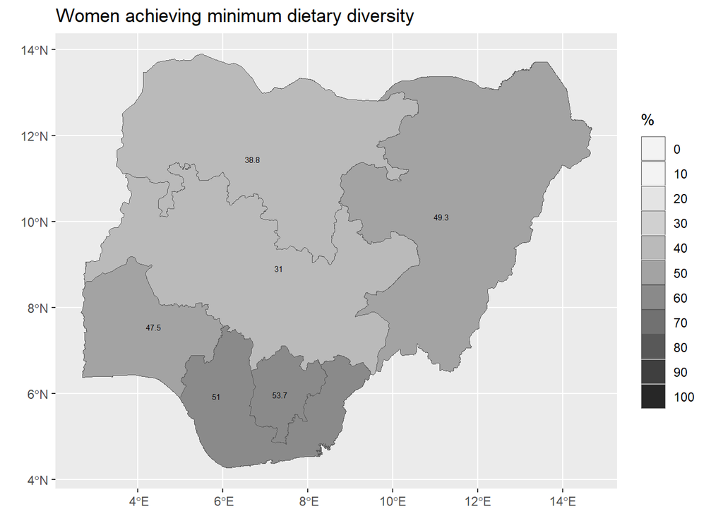

```r
ggplot(vect_gpz_geo_GHS) +
  geom_spatvector(aes(fill = W_min_DDS)) +
  geom_spatvector_text(aes(label = W_min_DDS), size = 2) +
  scale_fill_stepsn(
    n.breaks = 10,
    limits = c(0, 100),
    colours = hcl.colors(palette = "Grays", 10, rev = T),
    guide = "legend",
    na.value = "pink",
    labels = scales::comma
  ) +
  labs(title = "Women achieving minimum dietary diversity", fill = "%") +
  theme(
    plot.title = element_markdown(),
    legend.title = element_markdown(),
    axis.title = element_blank()
  )
```

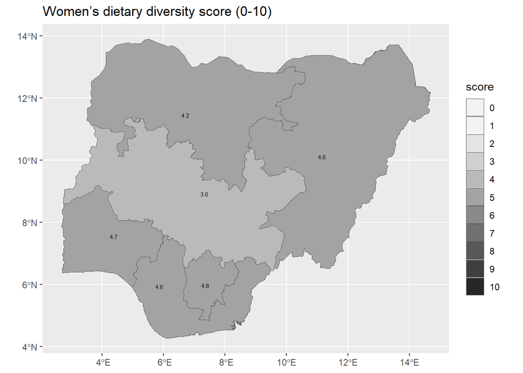

```r
ggplot(vect_gpz_geo_GHS) +
  geom_spatvector(aes(fill = DDS)) +
  geom_spatvector_text(aes(label = DDS), size = 2) +
  scale_fill_stepsn(
    n.breaks = 10,
    limits = c(0, 10),
    colours = hcl.colors(palette = "Grays", 10, rev = T),
    guide = "legend",
    na.value = "pink",
    labels = scales::comma
  ) +
  labs(title = "Women's dietary diversity score (0-10)", fill = "score") +
  theme(
    plot.title = element_markdown(),
    legend.title = element_markdown(),
    axis.title = element_blank()
  )
```

## Conclusion

The NFCMS data from 2021 show that overall most women do not achieve minimum dietary diversity. The zone with the highest percentage of women achieving MDD is South West. This is the only zone where a majority of women achieve MDD. The zone with the lowest percentage is North West, with only 13.3% of women achieving MDD.

The average MDD scores per zone range between 3 and 4.6. These are low scores, with the southern zones having the most diverse diets. North West zone has the least diverse diet. This indicator is consistent with the % of women achieving MDD.

The percentage of women achieving MDD from the 2024 GHS data show far higher percentages compared to the NFCMS data from 2021, especially in North West and North East zones. However, the South West was no longer the zone with the highest percentage, instead South East zone was the highest with 53.7%.

Both datasets are from reliable sources, but the GHS data are more recent.

# Macro-nutrient intake

## Total Energy intake

The NFCMS provides a list of the 10 food products that contribute most to energy intake for each zone. These data provide context to the macro-nutrient intake for each zone, and provide insights into the food basket composition for each zone.

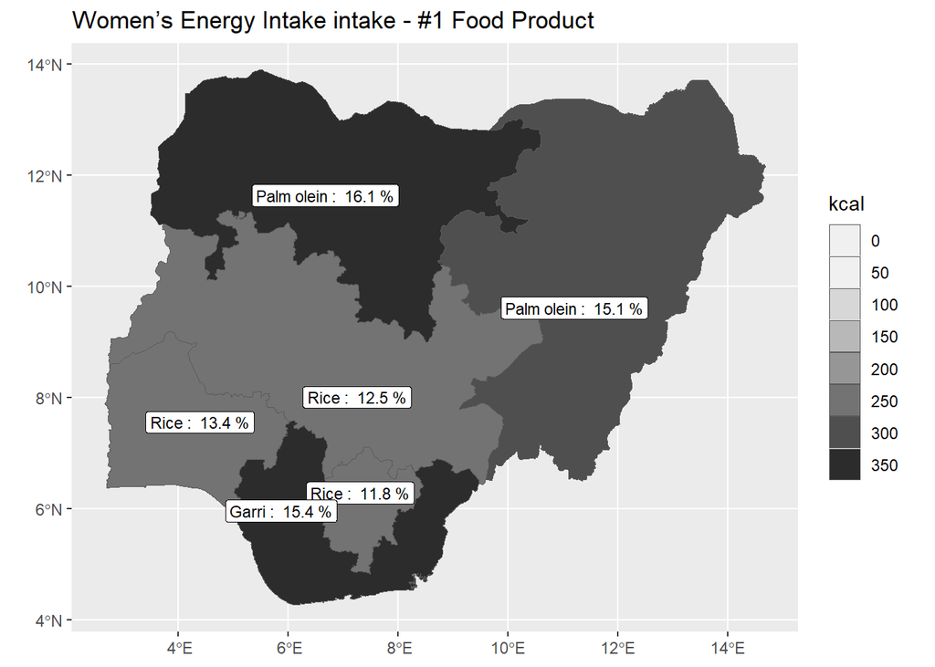

```r
ggplot(vect_gpz_geo_NFCMS_A10) +
  geom_spatvector(aes(fill = SN1_kcal)) +
  geom_spatvector_label(
    aes(label = paste(SN1_Name, ": ", SN1_pc, "%")),
    position = position_jitter(width = 0.1, height = 1.2, seed = 3),
    size = 3
  ) +
  scale_fill_stepsn(
    n.breaks = 10,
    limits = c(0, 350),
    colours = hcl.colors(palette = "Grays", 10, rev = T),
    guide = "legend",
    na.value = "pink",
    labels = scales::comma
  ) +
  labs(
    title = "Women's Energy Intake intake - #1 Food Product",
    fill = "kcal"
  ) +
  theme(
    plot.title = element_markdown(),
    legend.title = element_markdown(),
    axis.title = element_blank()
  )
```

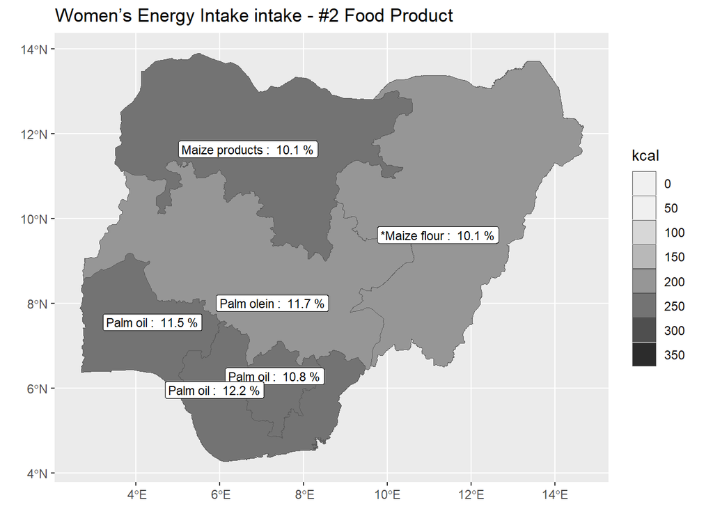

```r
ggplot(vect_gpz_geo_NFCMS_A10) +
  geom_spatvector(aes(fill = SN2_kcal)) +
  geom_spatvector_label(
    aes(label = paste(SN2_Name, ": ", SN2_pc, "%")),
    position = position_jitter(width = 0.1, height = 1.2, seed = 3),
    size = 3
  ) +
  scale_fill_stepsn(
    n.breaks = 10,
    limits = c(0, 350),
    colours = hcl.colors(palette = "Grays", 10, rev = T),
    guide = "legend",
    na.value = "pink",
    labels = scales::comma
  ) +
  labs(
    title = "Women's Energy Intake intake - #2 Food Product",
    fill = "kcal"
  ) +
  theme(
    plot.title = element_markdown(),
    legend.title = element_markdown(),
    axis.title = element_blank()
  )
```

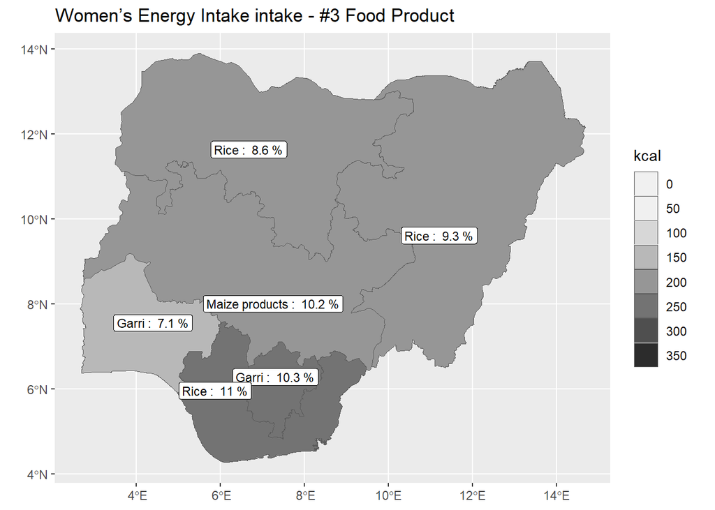

```r
ggplot(vect_gpz_geo_NFCMS_A10) +
  geom_spatvector(aes(fill = SN3_kcal)) +
  geom_spatvector_label(
    aes(label = paste(SN3_Name, ": ", SN3_pc, "%")),
    position = position_jitter(width = 0.1, height = 1.2, seed = 3),
    size = 3
  ) +
  scale_fill_stepsn(
    n.breaks = 10,
    limits = c(0, 350),
    colours = hcl.colors(palette = "Grays", 10, rev = T),
    guide = "legend",
    na.value = "pink",
    labels = scales::comma
  ) +
  labs(
    title = "Women's Energy Intake intake - #3 Food Product",
    fill = "kcal"
  ) +
  theme(
    plot.title = element_markdown(),
    legend.title = element_markdown(),
    axis.title = element_blank()
  )
```

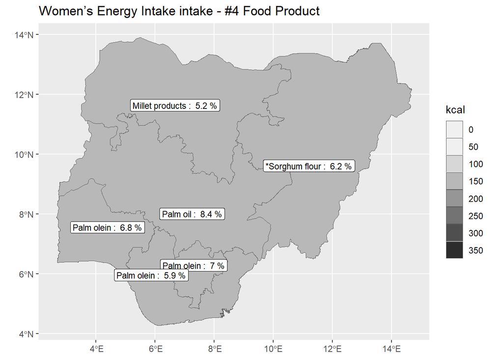

```r
ggplot(vect_gpz_geo_NFCMS_A10) +
  geom_spatvector(aes(fill = SN4_kcal)) +
  geom_spatvector_label(
    aes(label = paste(SN4_Name, ": ", SN4_pc, "%")),
    position = position_jitter(width = 0.1, height = 1.2, seed = 3),
    size = 3
  ) +
  scale_fill_stepsn(
    n.breaks = 10,
    limits = c(0, 350),
    colours = hcl.colors(palette = "Grays", 10, rev = T),
    guide = "legend",
    na.value = "pink",
    labels = scales::comma
  ) +
  labs(
    title = "Women's Energy Intake intake - #4 Food Product",
    fill = "kcal"
  ) +
  theme(
    plot.title = element_markdown(),
    legend.title = element_markdown(),
    axis.title = element_blank()
  )
```

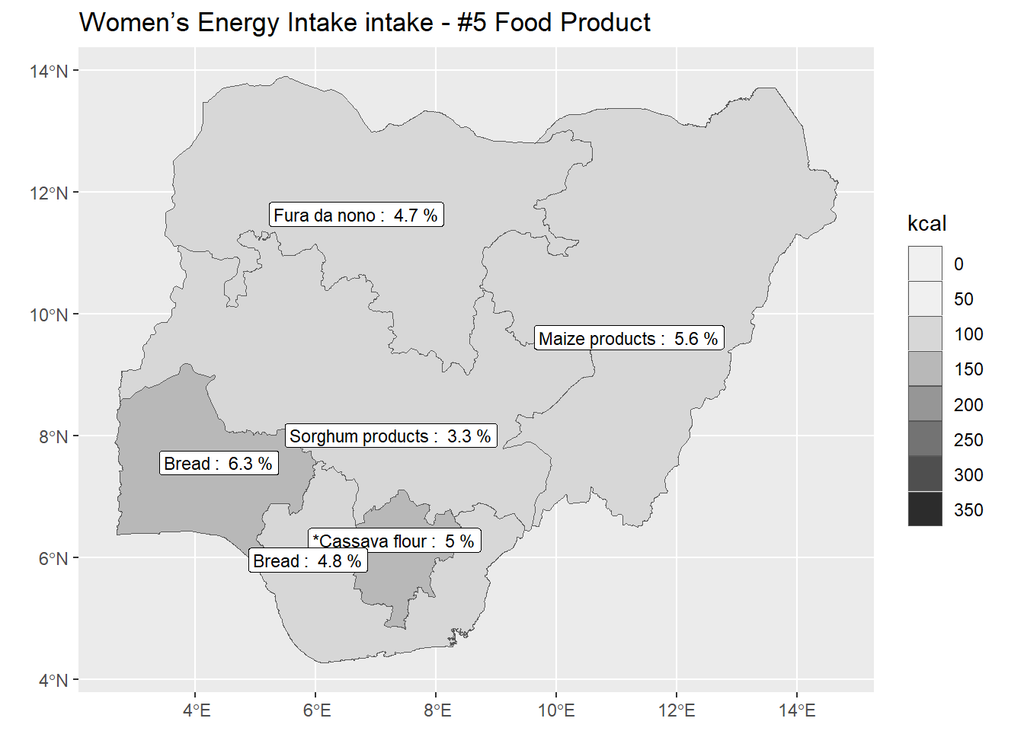

```r
ggplot(vect_gpz_geo_NFCMS_A10) +
  geom_spatvector(aes(fill = SN5_kcal)) +
  geom_spatvector_label(
    aes(label = paste(SN5_Name, ": ", SN5_pc, "%")),
    position = position_jitter(width = 0.1, height = 1.2, seed = 3),
    size = 3
  ) +
  scale_fill_stepsn(
    n.breaks = 10,
    limits = c(0, 350),
    colours = hcl.colors(palette = "Grays", 10, rev = T),
    guide = "legend",
    na.value = "pink",
    labels = scales::comma
  ) +
  labs(
    title = "Women's Energy Intake intake - #5 Food Product",
    fill = "kcal"
  ) +
  theme(
    plot.title = element_markdown(),
    legend.title = element_markdown(),
    axis.title = element_blank()
  )
```

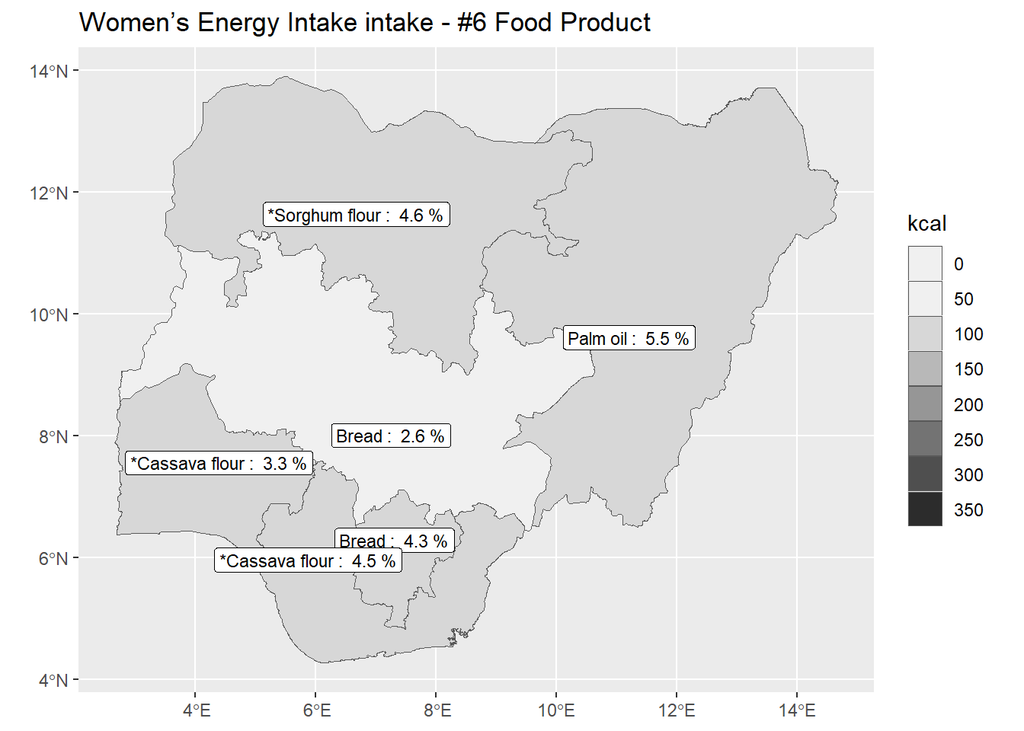

```r
ggplot(vect_gpz_geo_NFCMS_A10) +
  geom_spatvector(aes(fill = SN6_kcal)) +
  geom_spatvector_label(
    aes(label = paste(SN6_Name, ": ", SN6_pc, "%")),
    position = position_jitter(width = 0.1, height = 1.2, seed = 3),
    size = 3
  ) +
  scale_fill_stepsn(
    n.breaks = 10,
    limits = c(0, 350),
    colours = hcl.colors(palette = "Grays", 10, rev = T),
    guide = "legend",
    na.value = "pink",
    labels = scales::comma
  ) +
  labs(
    title = "Women's Energy Intake intake - #6 Food Product",
    fill = "kcal"
  ) +
  theme(
    plot.title = element_markdown(),
    legend.title = element_markdown(),
    axis.title = element_blank()
  )
```

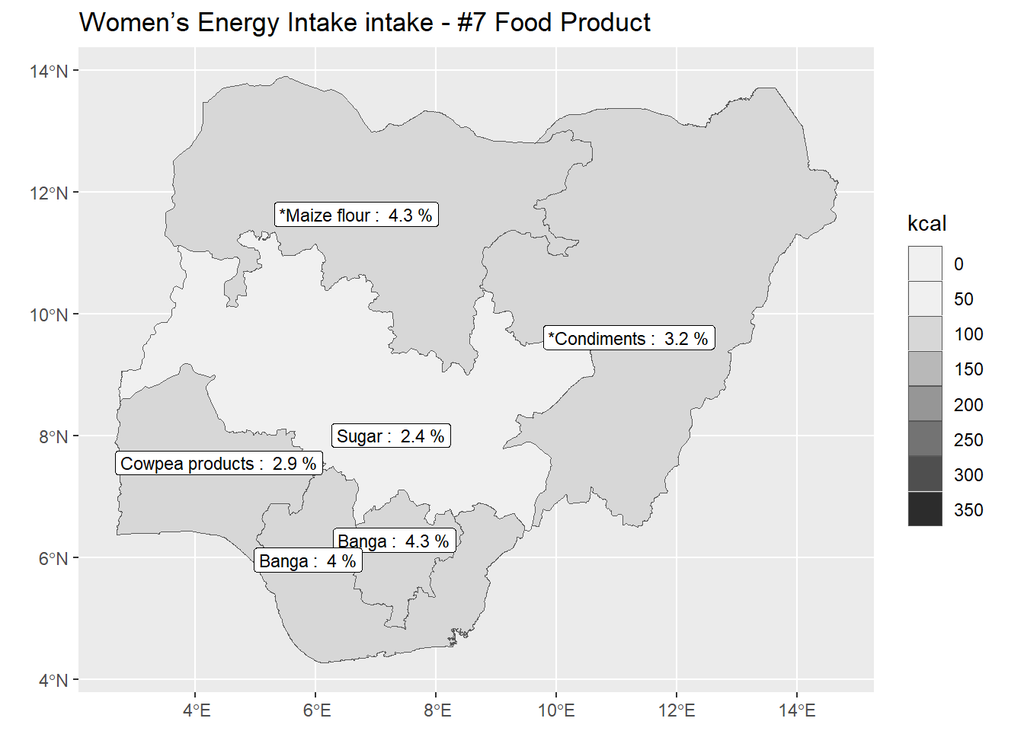

```r
ggplot(vect_gpz_geo_NFCMS_A10) +
  geom_spatvector(aes(fill = SN7_kcal)) +
  geom_spatvector_label(
    aes(label = paste(SN7_Name, ": ", SN7_pc, "%")),
    position = position_jitter(width = 0.1, height = 1.2, seed = 3),
    size = 3
  ) +
  scale_fill_stepsn(
    n.breaks = 10,
    limits = c(0, 350),
    colours = hcl.colors(palette = "Grays", 10, rev = T),
    guide = "legend",
    na.value = "pink",
    labels = scales::comma
  ) +
  labs(
    title = "Women's Energy Intake intake - #7 Food Product",
    fill = "kcal"
  ) +
  theme(
    plot.title = element_markdown(),
    legend.title = element_markdown(),
    axis.title = element_blank()
  )
```

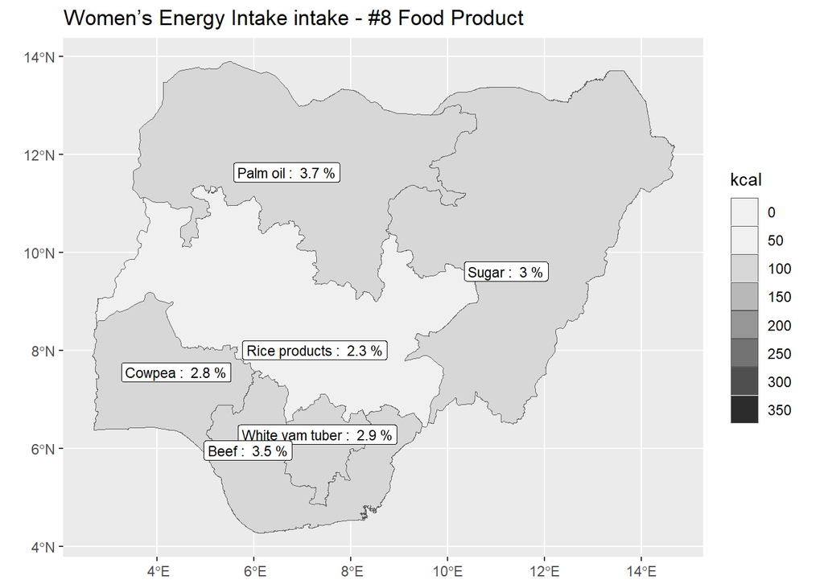

```r
ggplot(vect_gpz_geo_NFCMS_A10) +
  geom_spatvector(aes(fill = SN8_kcal)) +
  geom_spatvector_label(
    aes(label = paste(SN8_Name, ": ", SN8_pc, "%")),
    position = position_jitter(width = 0.1, height = 1.2, seed = 3),
    size = 3
  ) +
  scale_fill_stepsn(
    n.breaks = 10,
    limits = c(0, 350),
    colours = hcl.colors(palette = "Grays", 10, rev = T),
    guide = "legend",
    na.value = "pink",
    labels = scales::comma
  ) +
  labs(
    title = "Women's Energy Intake intake - #8 Food Product",
    fill = "kcal"
  ) +
  theme(
    plot.title = element_markdown(),
    legend.title = element_markdown(),
    axis.title = element_blank()
  )
```

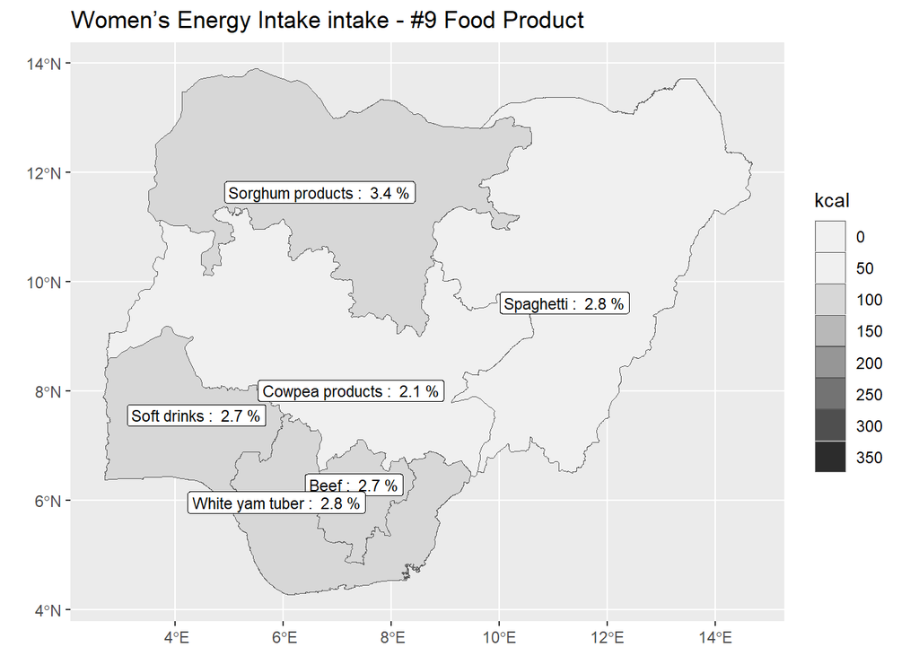

```r
ggplot(vect_gpz_geo_NFCMS_A10) +
  geom_spatvector(aes(fill = SN9_kcal)) +
  geom_spatvector_label(
    aes(label = paste(SN9_Name, ": ", SN9_pc, "%")),
    position = position_jitter(width = 0.1, height = 1.2, seed = 3),
    size = 3
  ) +
  scale_fill_stepsn(
    n.breaks = 10,
    limits = c(0, 350),
    colours = hcl.colors(palette = "Grays", 10, rev = T),
    guide = "legend",
    na.value = "pink",
    labels = scales::comma
  ) +
  labs(
    title = "Women's Energy Intake intake - #9 Food Product",
    fill = "kcal"
  ) +
  theme(
    plot.title = element_markdown(),
    legend.title = element_markdown(),
    axis.title = element_blank()
  )
```

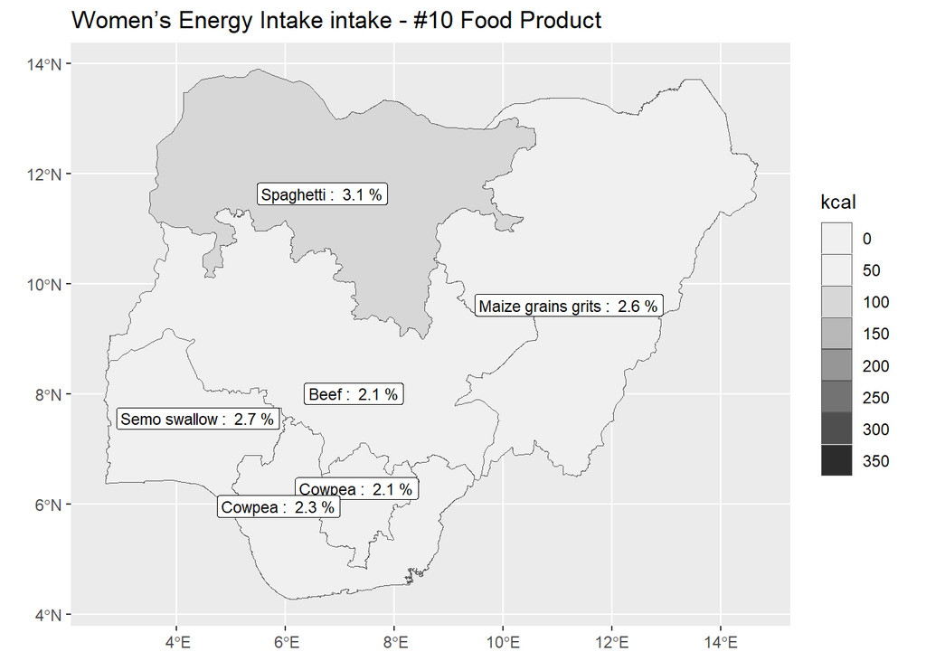

```r
ggplot(vect_gpz_geo_NFCMS_A10) +
  geom_spatvector(aes(fill = SN10_kcal)) +
  geom_spatvector_label(
    aes(label = paste(SN10_Name, ": ", SN10_pc, "%")),
    position = position_jitter(width = 0.1, height = 1.2, seed = 3),
    size = 3
  ) +
  scale_fill_stepsn(
    n.breaks = 10,
    limits = c(0, 350),
    colours = hcl.colors(palette = "Grays", 10, rev = T),
    guide = "legend",
    na.value = "pink",
    labels = scales::comma
  ) +
  labs(
    title = "Women's Energy Intake intake - #10 Food Product",
    fill = "kcal"
  ) +
  theme(
    plot.title = element_markdown(),
    legend.title = element_markdown(),
    axis.title = element_blank()
  )
```

## Total Protein intake

The NFCMS provides a list of the 10 food products that contribute most to protein intake for each zone. These data provide context to the macro-nutrient intake for each zone, and provide insights into the food basket composition for each zone.

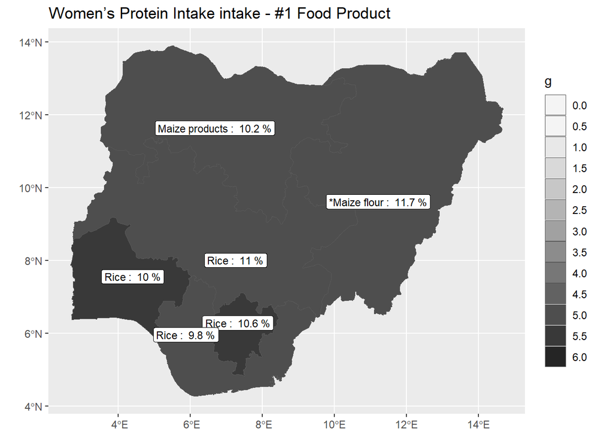

```r
ggplot(vect_gpz_geo_NFCMS_A12) +
  geom_spatvector(aes(fill = SN1_g)) +
  geom_spatvector_label(
    aes(label = paste(SN1_Name, ": ", SN1_pc, "%")),
    position = position_jitter(width = 0.1, height = 1.2, seed = 3),
    size = 3
  ) +
  scale_fill_stepsn(
    n.breaks = 10,
    limits = c(0, 6),
    colours = hcl.colors(palette = "Grays", 10, rev = T),
    guide = "legend",
    na.value = "pink",
    labels = scales::comma
  ) +
  labs(
    title = "Women's Protein Intake intake - #1 Food Product",
    fill = "g"
  ) +
  theme(
    plot.title = element_markdown(),
    legend.title = element_markdown(),
    axis.title = element_blank()
  )
```

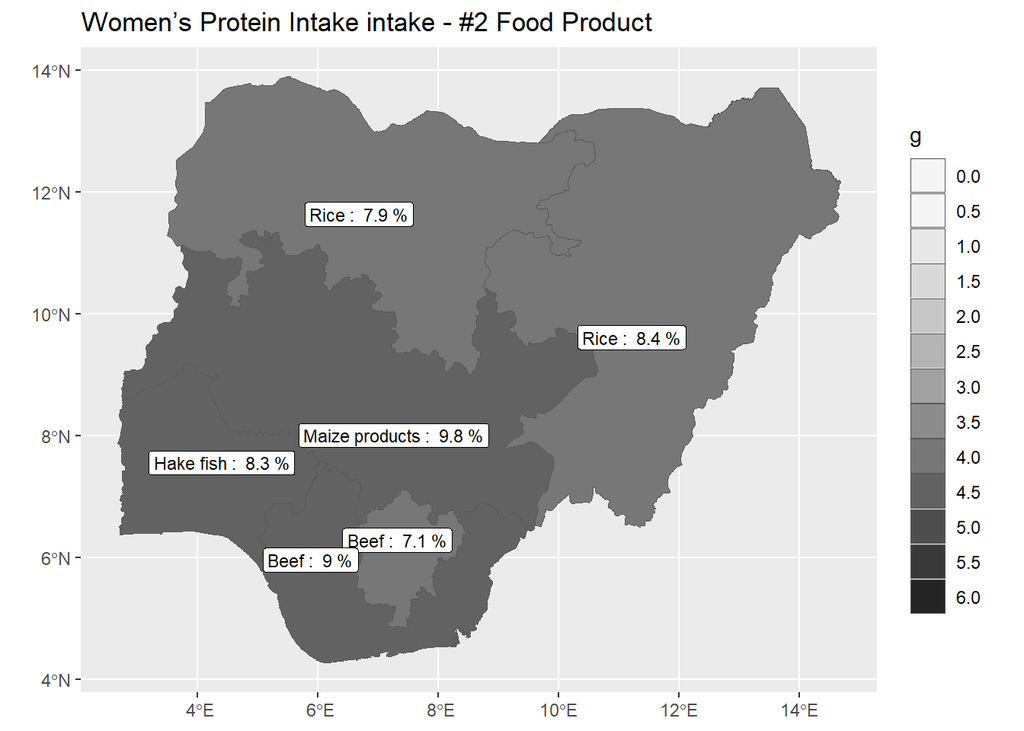

```r
ggplot(vect_gpz_geo_NFCMS_A12) +
  geom_spatvector(aes(fill = SN2_g)) +
  geom_spatvector_label(
    aes(label = paste(SN2_Name, ": ", SN2_pc, "%")),
    position = position_jitter(width = 0.1, height = 1.2, seed = 3),
    size = 3
  ) +
  scale_fill_stepsn(
    n.breaks = 10,
    limits = c(0, 6),
    colours = hcl.colors(palette = "Grays", 10, rev = T),
    guide = "legend",
    na.value = "pink",
    labels = scales::comma
  ) +
  labs(
    title = "Women's Protein Intake intake - #2 Food Product",
    fill = "g"
  ) +
  theme(
    plot.title = element_markdown(),
    legend.title = element_markdown(),
    axis.title = element_blank()
  )
```

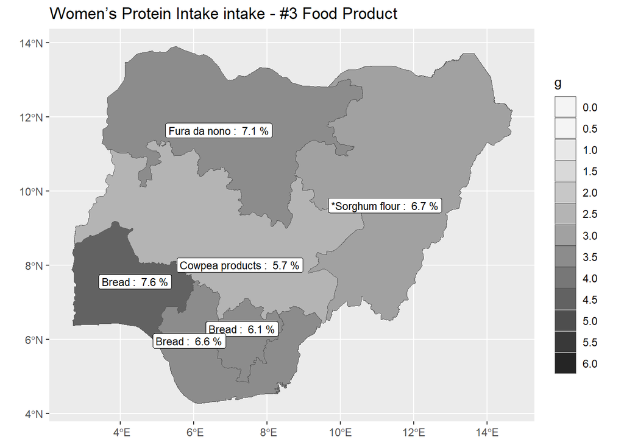

```r
ggplot(vect_gpz_geo_NFCMS_A12) +
  geom_spatvector(aes(fill = SN3_g)) +
  geom_spatvector_label(
    aes(label = paste(SN3_Name, ": ", SN3_pc, "%")),
    position = position_jitter(width = 0.1, height = 1.2, seed = 3),
    size = 3
  ) +
  scale_fill_stepsn(
    n.breaks = 10,
    limits = c(0, 6),
    colours = hcl.colors(palette = "Grays", 10, rev = T),
    guide = "legend",
    na.value = "pink",
    labels = scales::comma
  ) +
  labs(
    title = "Women's Protein Intake intake - #3 Food Product",
    fill = "g"
  ) +
  theme(
    plot.title = element_markdown(),
    legend.title = element_markdown(),
    axis.title = element_blank()
  )
```

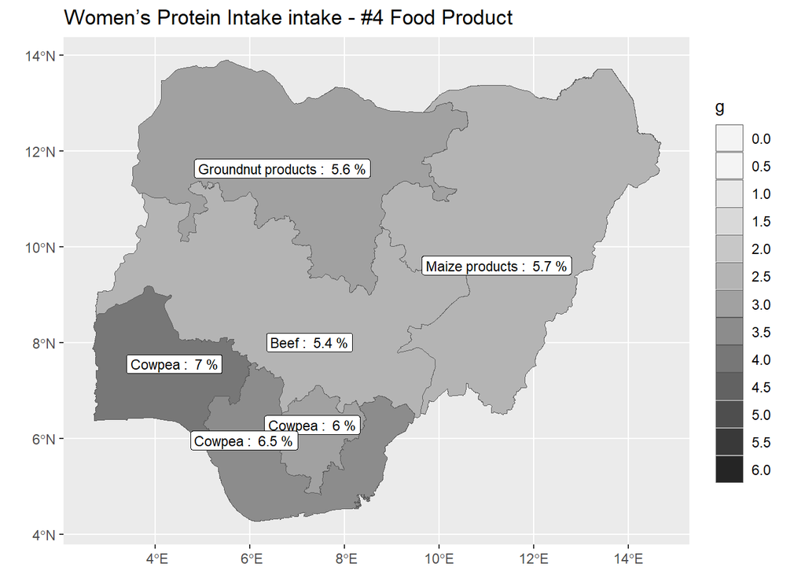

```r
ggplot(vect_gpz_geo_NFCMS_A12) +
  geom_spatvector(aes(fill = SN4_g)) +
  geom_spatvector_label(
    aes(label = paste(SN4_Name, ": ", SN4_pc, "%")),
    position = position_jitter(width = 0.1, height = 1.2, seed = 3),
    size = 3
  ) +
  scale_fill_stepsn(
    n.breaks = 10,
    limits = c(0, 6),
    colours = hcl.colors(palette = "Grays", 10, rev = T),
    guide = "legend",
    na.value = "pink",
    labels = scales::comma
  ) +
  labs(
    title = "Women's Protein Intake intake - #4 Food Product",
    fill = "g"
  ) +
  theme(
    plot.title = element_markdown(),
    legend.title = element_markdown(),
    axis.title = element_blank()
  )
```

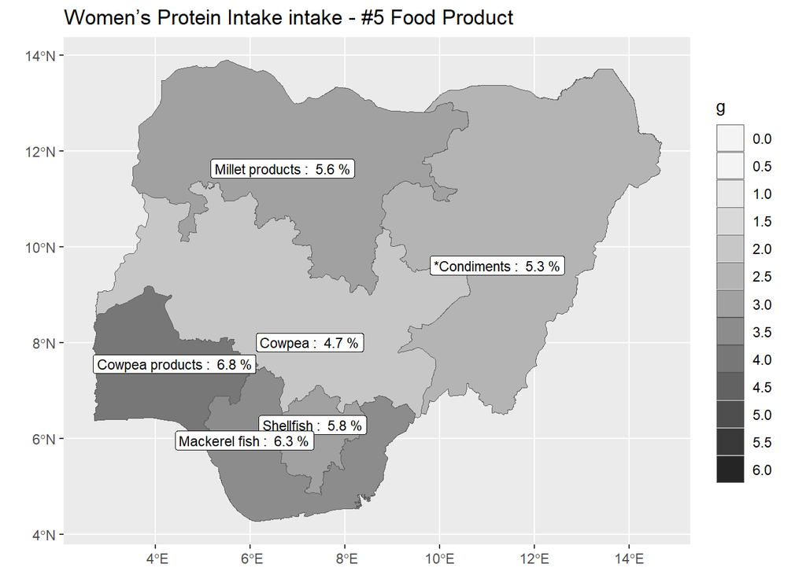

```r
ggplot(vect_gpz_geo_NFCMS_A12) +
  geom_spatvector(aes(fill = SN5_g)) +
  geom_spatvector_label(
    aes(label = paste(SN5_Name, ": ", SN5_pc, "%")),
    position = position_jitter(width = 0.1, height = 1.2, seed = 3),
    size = 3
  ) +
  scale_fill_stepsn(
    n.breaks = 10,
    limits = c(0, 6),
    colours = hcl.colors(palette = "Grays", 10, rev = T),
    guide = "legend",
    na.value = "pink",
    labels = scales::comma
  ) +
  labs(
    title = "Women's Protein Intake intake - #5 Food Product",
    fill = "g"
  ) +
  theme(
    plot.title = element_markdown(),
    legend.title = element_markdown(),
    axis.title = element_blank()
  )
```

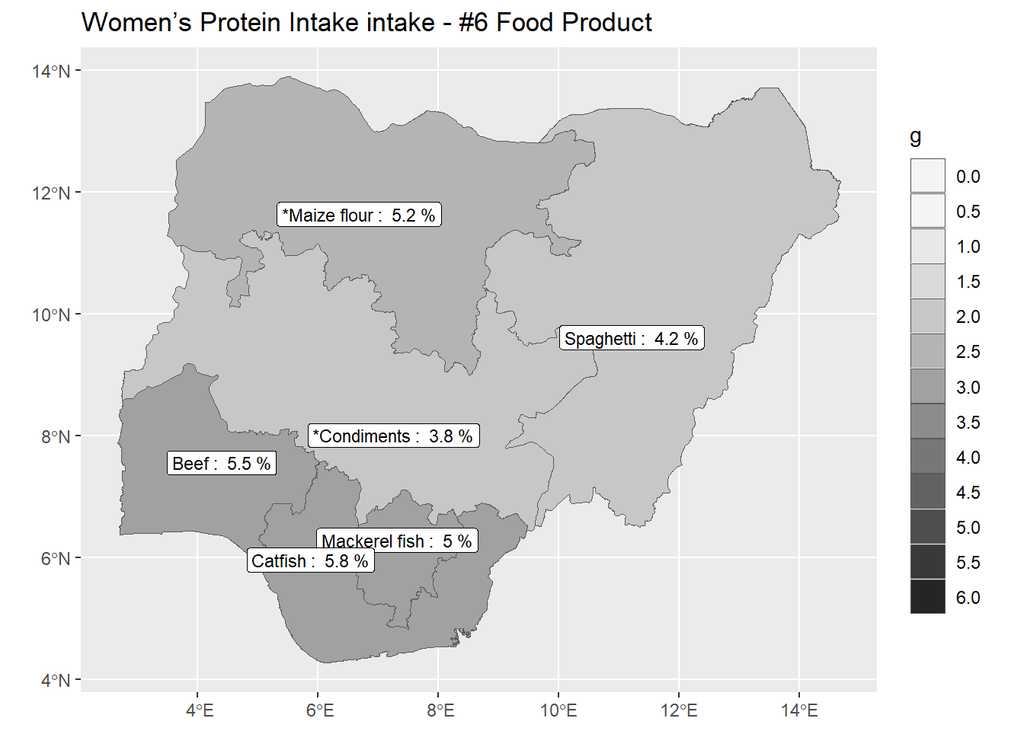

```r
ggplot(vect_gpz_geo_NFCMS_A12) +
  geom_spatvector(aes(fill = SN6_g)) +
  geom_spatvector_label(
    aes(label = paste(SN6_Name, ": ", SN6_pc, "%")),
    position = position_jitter(width = 0.1, height = 1.2, seed = 3),
    size = 3
  ) +
  scale_fill_stepsn(
    n.breaks = 10,
    limits = c(0, 6),
    colours = hcl.colors(palette = "Grays", 10, rev = T),
    guide = "legend",
    na.value = "pink",
    labels = scales::comma
  ) +
  labs(
    title = "Women's Protein Intake intake - #6 Food Product",
    fill = "g"
  ) +
  theme(
    plot.title = element_markdown(),
    legend.title = element_markdown(),
    axis.title = element_blank()
  )
```

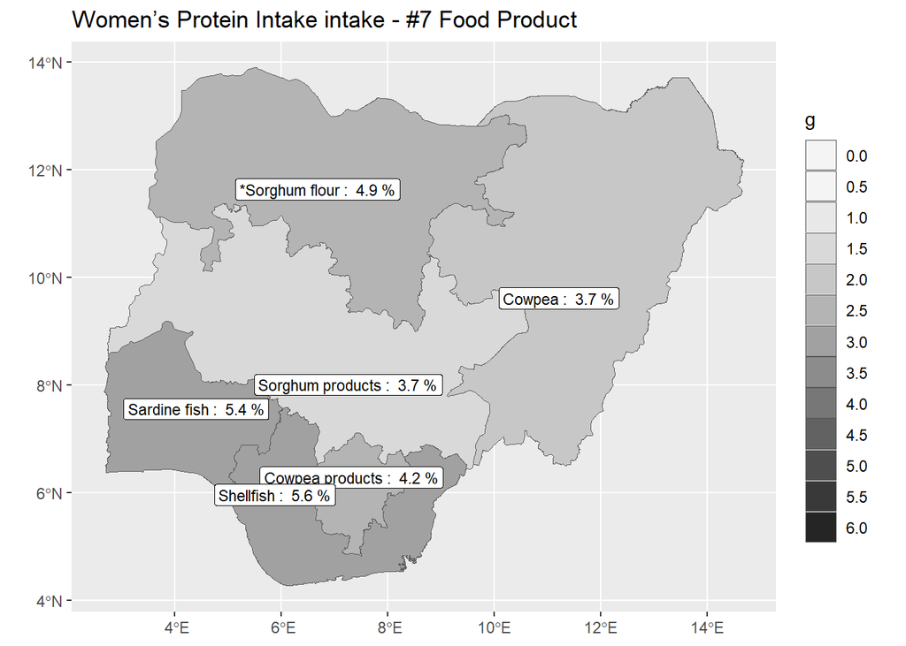

```r
ggplot(vect_gpz_geo_NFCMS_A12) +
  geom_spatvector(aes(fill = SN7_g)) +
  geom_spatvector_label(
    aes(label = paste(SN7_Name, ": ", SN7_pc, "%")),
    position = position_jitter(width = 0.1, height = 1.2, seed = 3),
    size = 3
  ) +
  scale_fill_stepsn(
    n.breaks = 10,
    limits = c(0, 6),
    colours = hcl.colors(palette = "Grays", 10, rev = T),
    guide = "legend",
    na.value = "pink",
    labels = scales::comma
  ) +
  labs(
    title = "Women's Protein Intake intake - #7 Food Product",
    fill = "g"
  ) +
  theme(
    plot.title = element_markdown(),
    legend.title = element_markdown(),
    axis.title = element_blank()
  )
```

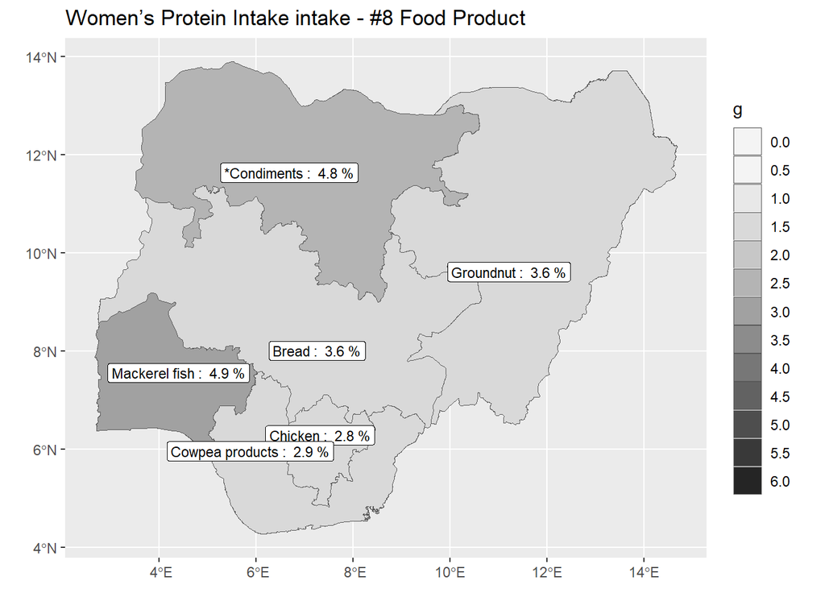

```r
ggplot(vect_gpz_geo_NFCMS_A12) +
  geom_spatvector(aes(fill = SN8_g)) +
  geom_spatvector_label(
    aes(label = paste(SN8_Name, ": ", SN8_pc, "%")),
    position = position_jitter(width = 0.1, height = 1.2, seed = 3),
    size = 3
  ) +
  scale_fill_stepsn(
    n.breaks = 10,
    limits = c(0, 6),
    colours = hcl.colors(palette = "Grays", 10, rev = T),
    guide = "legend",
    na.value = "pink",
    labels = scales::comma
  ) +
  labs(
    title = "Women's Protein Intake intake - #8 Food Product",
    fill = "g"
  ) +
  theme(
    plot.title = element_markdown(),
    legend.title = element_markdown(),
    axis.title = element_blank()
  )
```

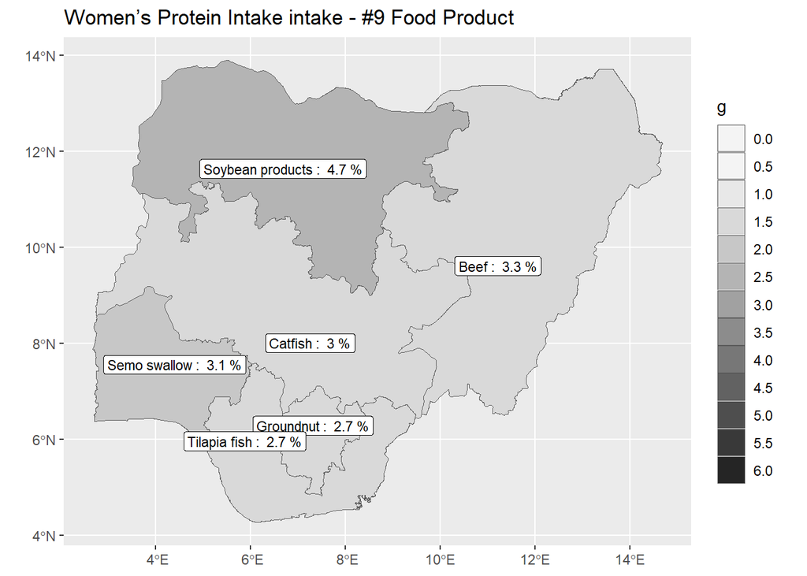

```r
ggplot(vect_gpz_geo_NFCMS_A12) +
  geom_spatvector(aes(fill = SN9_g)) +
  geom_spatvector_label(
    aes(label = paste(SN9_Name, ": ", SN9_pc, "%")),
    position = position_jitter(width = 0.1, height = 1.2, seed = 3),
    size = 3
  ) +
  scale_fill_stepsn(
    n.breaks = 10,
    limits = c(0, 6),
    colours = hcl.colors(palette = "Grays", 10, rev = T),
    guide = "legend",
    na.value = "pink",
    labels = scales::comma
  ) +
  labs(
    title = "Women's Protein Intake intake - #9 Food Product",
    fill = "g"
  ) +
  theme(
    plot.title = element_markdown(),
    legend.title = element_markdown(),
    axis.title = element_blank()
  )
```

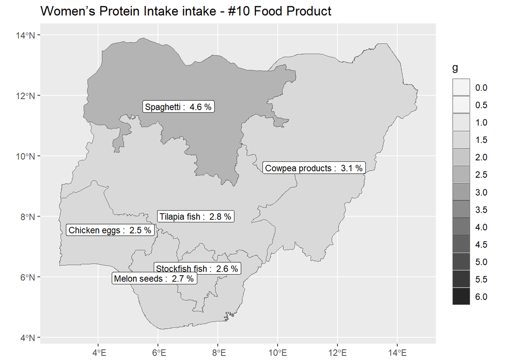

```r
ggplot(vect_gpz_geo_NFCMS_A12) +
  geom_spatvector(aes(fill = SN10_g)) +
  geom_spatvector_label(
    aes(label = paste(SN10_Name, ": ", SN10_pc, "%")),
    position = position_jitter(width = 0.1, height = 1.2, seed = 3),
    size = 3
  ) +
  scale_fill_stepsn(
    n.breaks = 10,
    limits = c(0, 6),
    colours = hcl.colors(palette = "Grays", 10, rev = T),
    guide = "legend",
    na.value = "pink",
    labels = scales::comma
  ) +
  labs(
    title = "Women's Protein Intake intake - #10 Food Product",
    fill = "g"
  ) +
  theme(
    plot.title = element_markdown(),
    legend.title = element_markdown(),
    axis.title = element_blank()
  )
```

## Total Carbohydrate intake

The NFCMS provides a list of the 10 food products that contribute most to carbohydrate intake for each zone. These data provide context to the macro-nutrient intake for each zone, and provide insights into the food basket composition for each zone.

[figure not shown]

```r
ggplot(vect_gpz_geo_NFCMS_A17) +
  geom_spatvector(aes(fill = SN1_g)) +
  geom_spatvector_label(
    aes(label = paste(SN1_Name, ": ", SN2_pc, "%")),
    position = position_jitter(width = 0.1, height = 1.2, seed = 3),
    size = 3
  ) +
  scale_fill_stepsn(
    n.breaks = 10,
    limits = c(0, 75),
    colours = hcl.colors(palette = "Grays", 10, rev = T),
    guide = "legend",
    na.value = "pink",
    labels = scales::comma
  ) +
  labs(
    title = "Women's Carbohydrate Intake intake - #1 Food Product",
    fill = "g"
  ) +
  theme(
    plot.title = element_markdown(),
    legend.title = element_markdown(),
    axis.title = element_blank()
  )
```

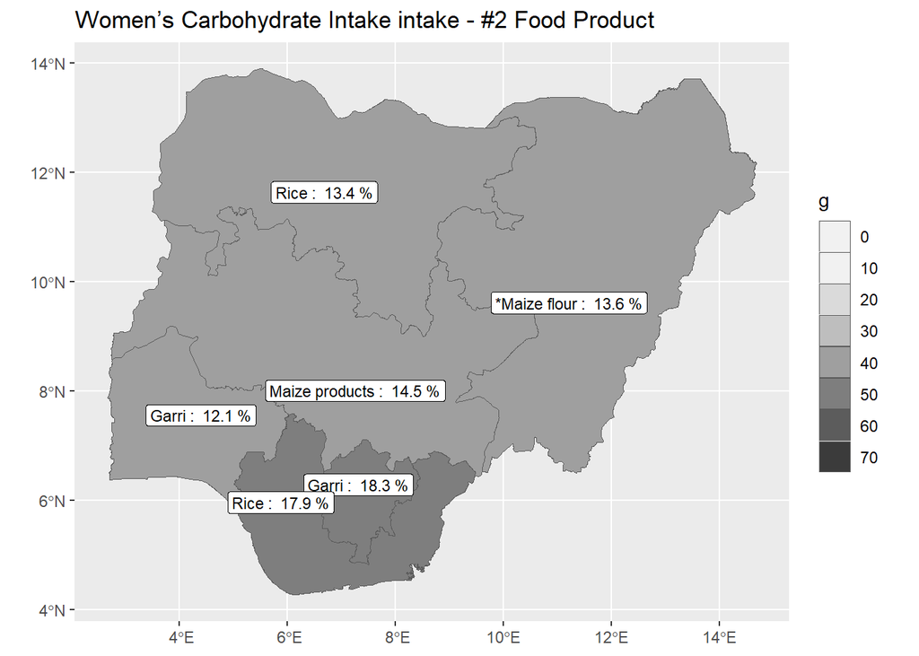

```r
ggplot(vect_gpz_geo_NFCMS_A17) +
  geom_spatvector(aes(fill = SN2_g)) +
  geom_spatvector_label(
    aes(label = paste(SN2_Name, ": ", SN2_pc, "%")),
    position = position_jitter(width = 0.1, height = 1.2, seed = 3),
    size = 3
  ) +
  scale_fill_stepsn(
    n.breaks = 10,
    limits = c(0, 75),
    colours = hcl.colors(palette = "Grays", 10, rev = T),
    guide = "legend",
    na.value = "pink",
    labels = scales::comma
  ) +
  labs(
    title = "Women's Carbohydrate Intake intake - #2 Food Product",
    fill = "g"
  ) +
  theme(
    plot.title = element_markdown(),
    legend.title = element_markdown(),
    axis.title = element_blank()
  )
```

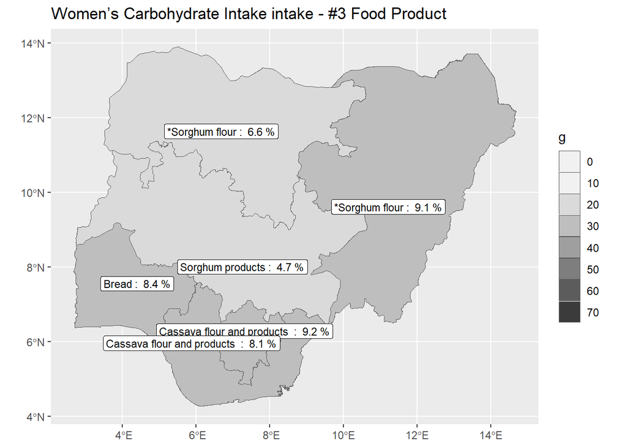

```r
ggplot(vect_gpz_geo_NFCMS_A17) +
  geom_spatvector(aes(fill = SN3_g)) +
  geom_spatvector_label(
    aes(label = paste(SN3_Name, ": ", SN3_pc, "%")),
    position = position_jitter(width = 0.1, height = 1.2, seed = 3),
    size = 3
  ) +
  scale_fill_stepsn(
    n.breaks = 10,
    limits = c(0, 75),
    colours = hcl.colors(palette = "Grays", 10, rev = T),
    guide = "legend",
    na.value = "pink",
    labels = scales::comma
  ) +
  labs(
    title = "Women's Carbohydrate Intake intake - #3 Food Product",
    fill = "g"
  ) +
  theme(
    plot.title = element_markdown(),
    legend.title = element_markdown(),
    axis.title = element_blank()
  )
```